# DS4IR

Análise Exploratória

Professor Davi Moreira

Professor Rafael Magalhães

24-07-2020

> “In God we trust; all others must bring data.

> — William Edwards Deming

## Programa

- Medidas de posição
- Medidas de dispersão
- Tabelas de contingência
- Resumos gráficos
- Interpretação de estatísticas descritivas

## Motivação: Civilian Victimization during Wartime

- Após os ataques de 11 de setembro, os EUA e aliados invadiram o Afeganistão com o objetivo de distruir a al-Qaeda.
- Em 2003 a OTAN passa a se envolver no conflito com o envio de tropas de segurança (International Security Assistance Force - ISAF).
- Entre outras ações, a ISAF se engajou numa campanha de assistência econômica para ganhar apoio civil.

## Motivação: Civilian Victimization during Wartime

- Para avaliar o sucesso dessa campanha era essencial mensurar a opinião dos civis durante a guerra.
- Realizar esse tipo de consulta à população em meio a um conflito armado não é trivial. Além de dificuldades operacionais para pesquisa, a população pode omitir e dificultar a coleta de informações.
- Um grupo de cientistas enfrentou esse desafio e é o resultado desse trabalho que vamos utilizar em aula.

## Motivação: referência

[Lyall, Jason, Graeme Blair, and Kosuke Imai. 2013. “Explaining Support for Combatants during Wartime: A Survey Experiment in Afghanistan.” American Political Science Review 107(4): 679–705.](https://www.cambridge.org/core/journals/american-political-science-review/article/explaining-support-for-combatants-during-wartime-a-survey-experiment-in-afghanistan/B0E55BA87D4EBF66F0BF6135959541A7)

[Blair, Graeme, Kosuke Imai, and Jason Lyall. 2014. “Comparing and Combining List and Endorsement Experiments: Evidence from Afghanistan.” American Journal of Political Science 58(4): 1043–63.](https://onlinelibrary.wiley.com/doi/abs/10.1111/ajps.12086)

## Importando dados

```r
afghan <- read_csv2(here("data", "afghan.csv"))
```

Vamos consultar nossa base de dados!

## Medidas de posição

```r
# Máximo
max(afghan$educ.years)

# Mínimo
min(afghan$educ.years)

# Média Aritmética
mean(afghan$educ.years)

# Mediana
median(afghan$educ.years)
```

## Medidas de posição

```r
# Quantis
summary(afghan$educ.years)

# Percentis / Decis...
quantile(afghan$educ.years, probs = seq(0,1, .25))
```

## Medidas de posição

Já vimos uma função que permite obter as principais medidas de posição de uma só vez. Com ela, não precisamos consultar uma a uma para descrever nossos dados:

```r
afghan %>%
  select(age, educ.years, employed, income) %>%
  summary()
```

## Medidas de posição

Por padrão, carregar a base de dados com a função `read_csv()` não transforma strings em fatores. Podemos usar a função `count()` para ter um resumo dos diferentes níveis da variável `income`.

```r
count(afghan, income)
```

## Tabelas de contingência

**Survey question**

“Over the past year, have you or anyone in your family suffered harm due to the actions of the Foreign Forces / the Taliban?”

```r
afghan %>%
  filter(!is.na(violent.exp.ISAF), !is.na(violent.exp.taliban)) %>%
  group_by(violent.exp.ISAF, violent.exp.taliban) %>%
  count() %>%
  ungroup() %>%
  mutate(prop = n / sum(n))
```

## Mosaic Plot

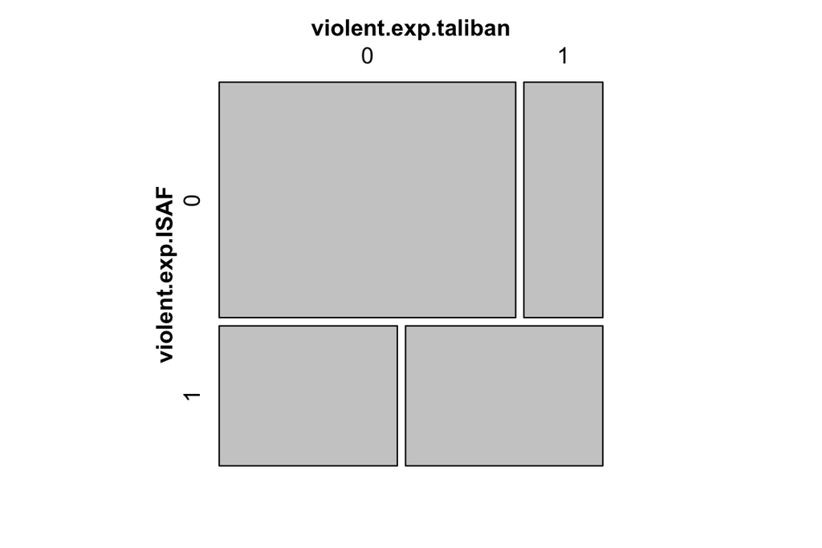

Using Graphs Instead of Tables in Political Science.

## Medidas de dispersão

```r
# Amplitude
max(afghan$educ.years) - min(afghan$educ.years)
# ou
range(afghan$educ.years)[2] - range(afghan$educ.years)[1]

# Variância
var(afghan$educ.years)

# Desvio padrão
sd(afghan$educ.years)
# ou
afghan %>% select(educ.years) %>% var %>% sqrt
```

## Exercicio

A base de dados a seguir apresenta o desempenho de duas turmas numa prova de matemática. Analise os dados e indique a principal diferença entre elas.

```r
mat <- tibble(T1 = c(7,3,5,6,4),
              T2 = c(rep(5, 5)))
```

## Visualizando a distribuição univariada - Barplot

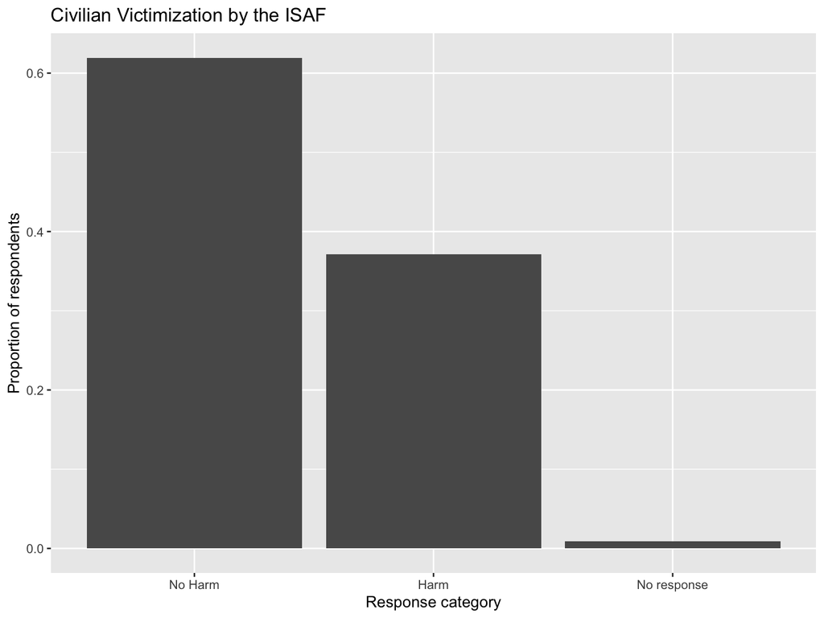

## Visualizando a distribuição univariada - Histogram

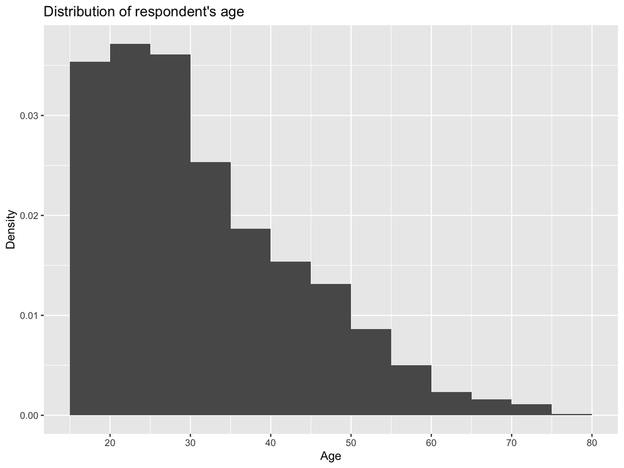

## Visualizando a distribuição univariada - Histogram

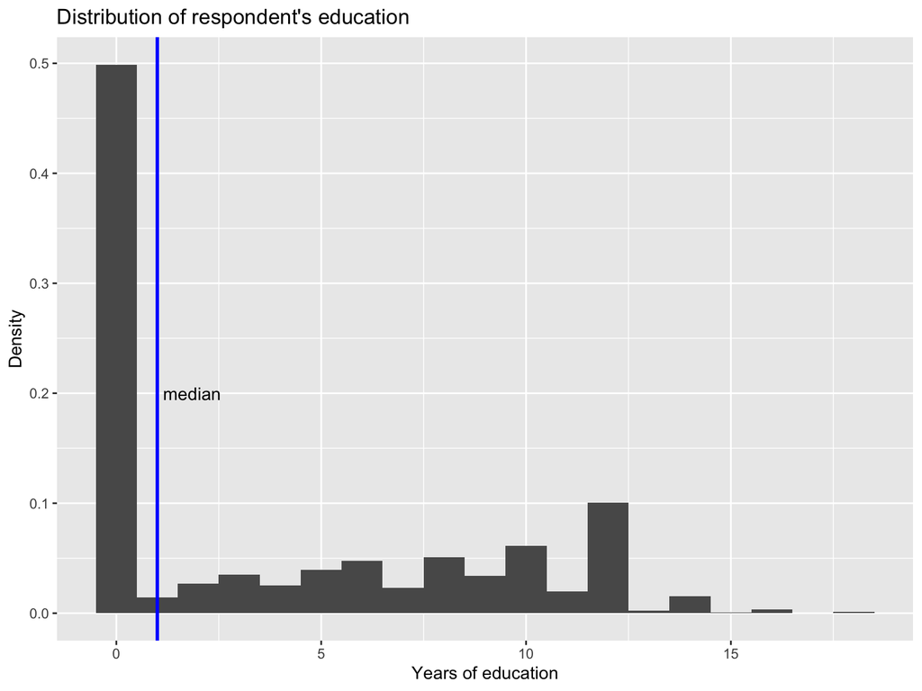

## Visualizando a distribuição univariada - Boxplot

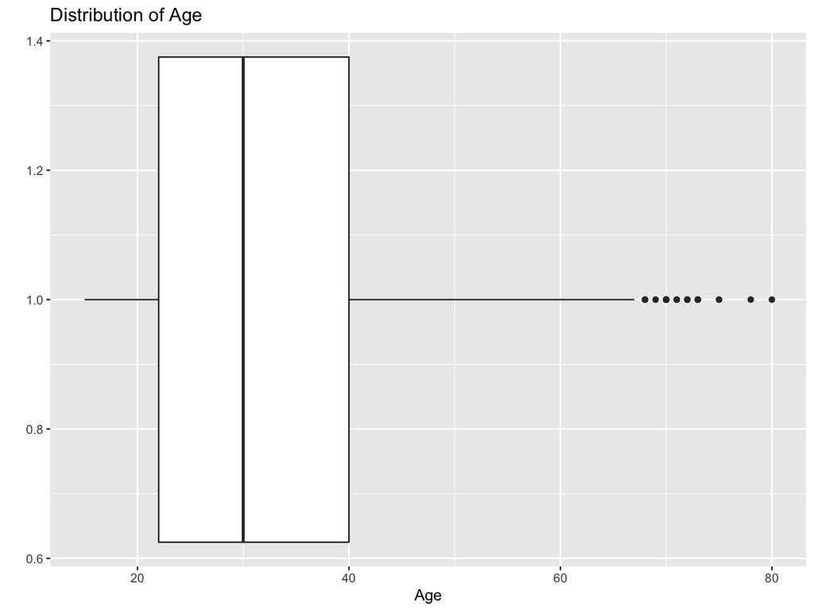

## Visualizando a distribuição univariada - Boxplot

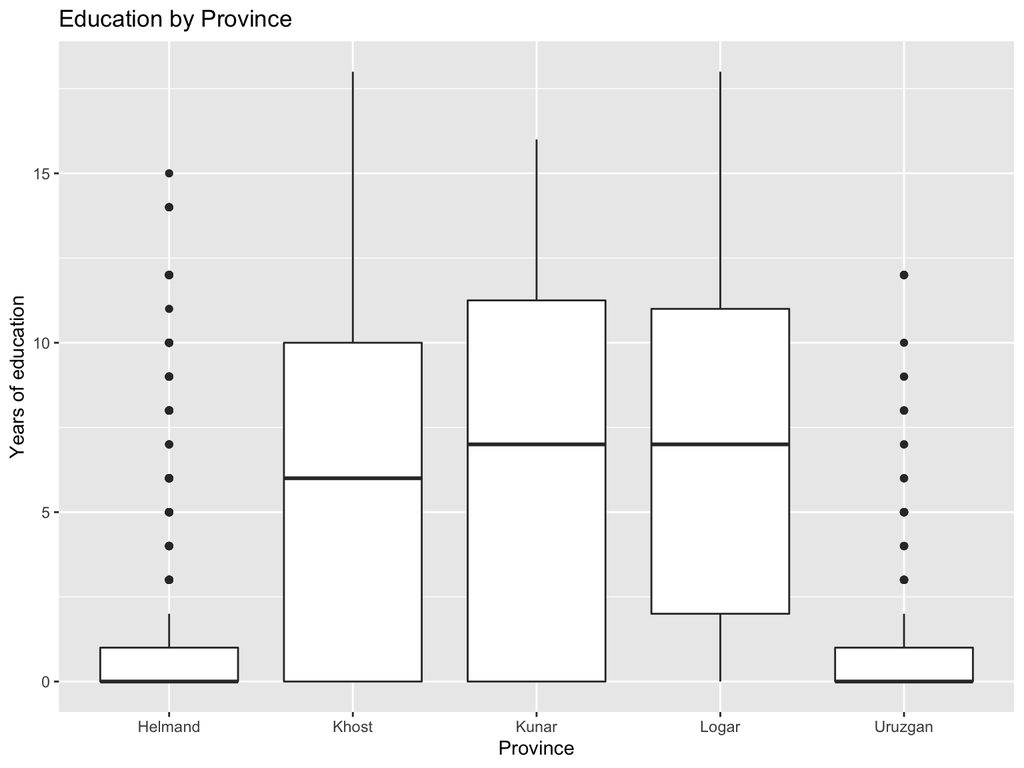

## Visualizando a distribuição univariada - Violin plot

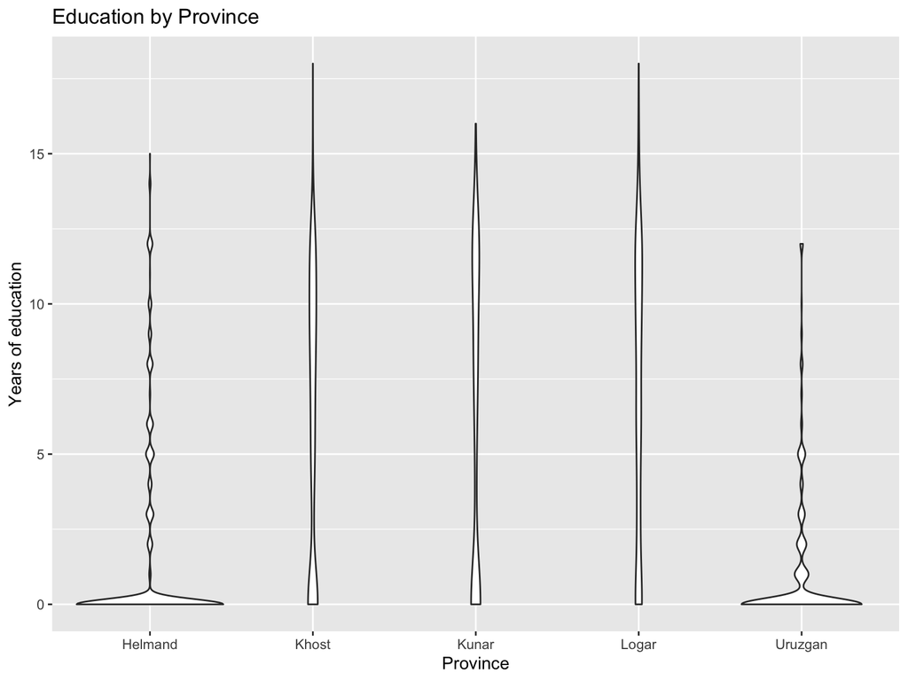

## Covariação

## Motivação: Medindo a polarização política

- Cientistas socias utilizam modelos de mensuração para sumarizar e entender comportamentos, atitudes e padrões de atividade humana.
- O exemplo mais proeminente de mensuração na ciência política é a polarização resultante do padrão de votação nominal dos congressistas.
- Nessa parte da aula vamos nos dedicar à análise dos pontos ideais dos congressistas americanos estimada pelo modelo DW-NOMINATE.

**Referência**: [Polarized America: The Dance of Ideology and Unequal Riches](https://mitpress.mit.edu/books/polarized-america-second-edition)

## Importando dados

```r
congress_us <- read_csv2(here("data", "congress.csv"))
```

Vamos consultar nossa base de dados!

## Gráfico de dispersão

Pontos ideais dos congressistas americanos nas legislaturas 80 (1947-1949) e 112 (2011-2013) em duas dimensões: *economic and racial*.

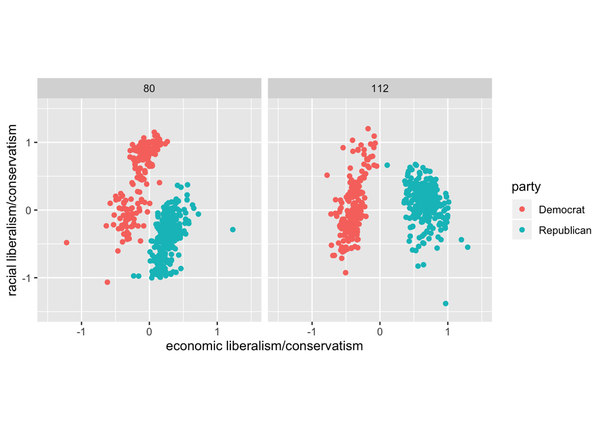

## Ilustração da importância do modelo

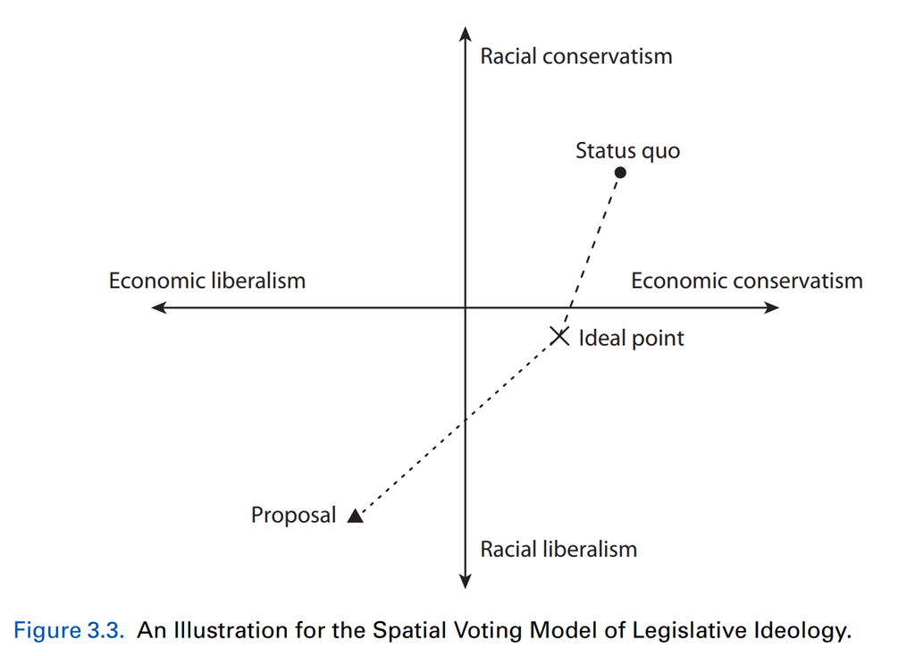

[Quantitative Social Science](http://qss.princeton.press/)

## Gráfico de linha - *Time Series Plot*

Com os dados de votação por congressista, qual seria um boa medida descritiva para analisar o padrão de votação dos partidos em uma dimensão específica? Por exemplo, na dimensão econômica (`dwnom1`).

## Gráfico de linha - *Time Series Plot*

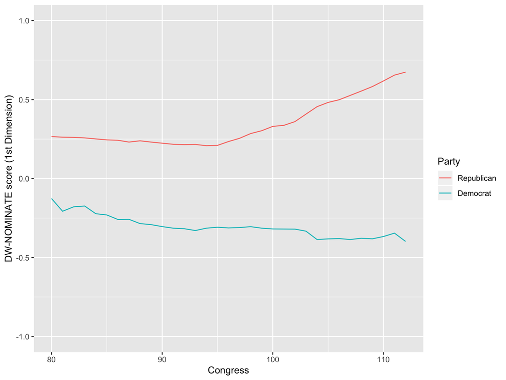

## Exercício:

Reproduza a análise considerando agora a dimensão racial (`dwnom2`).

## Correlação

[xkcd](https://xkcd.com/552/)

## Correlação

Retomando nosso exemplo:

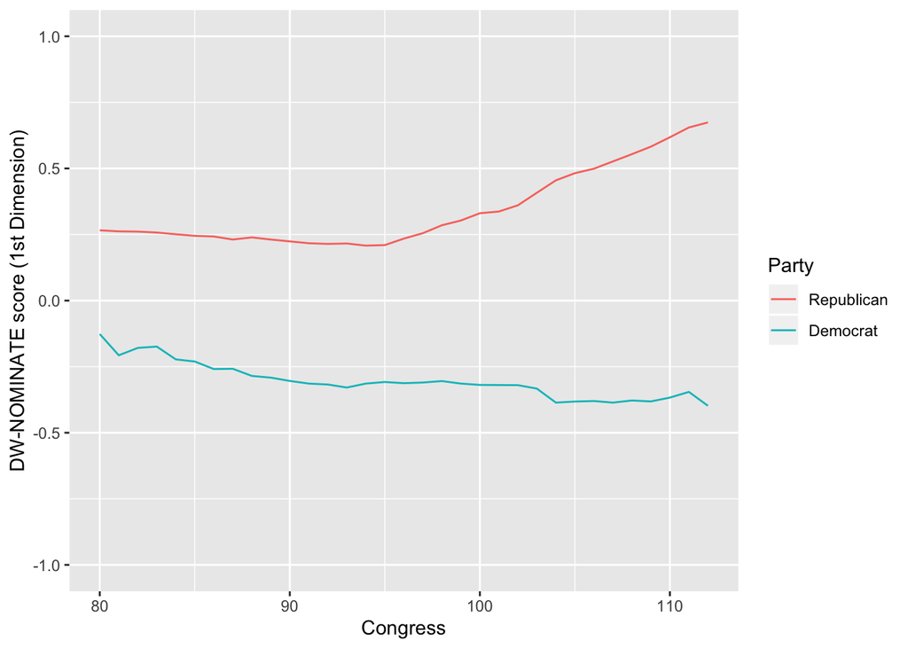

## Correlação

Calculando a polarização:

```r
party_polarization <-
  congress_us %>%
  group_by(congress, party) %>%
  summarise(dwnom1 = median(dwnom1)) %>%
  filter(party %in% c("Democrat", "Republican")) %>%
  spread(party, dwnom1) %>%
  mutate(polarization = Republican - Democrat)
```

## Exercício:

Desenvolva um gráfico que nos ajude a visualizar a variável criada.

## Correlação

Questão: estaria a desigualdade econômica associada à polarização?

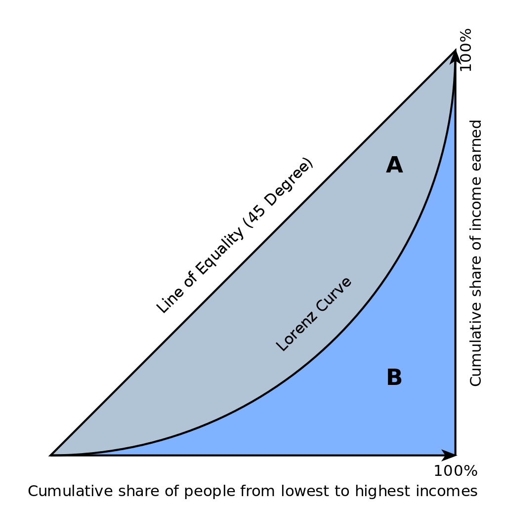

[wiki](https://en.wikipedia.org/wiki/Gini_coefficient)

O coeficiente de Gini é igual à área $A$ dividida pela soma das áreas $A+B$, $Gini = A/(A + B)$.

## Correlação

Questão: estaria o aumento da desigualdade econômica associada à polarização?

```r
gini_us <- read_csv2(here("data", "gini_us.csv"))
```

## Correlação

Questão: estaria o aumento da desigualdade econômica associada à polarização?

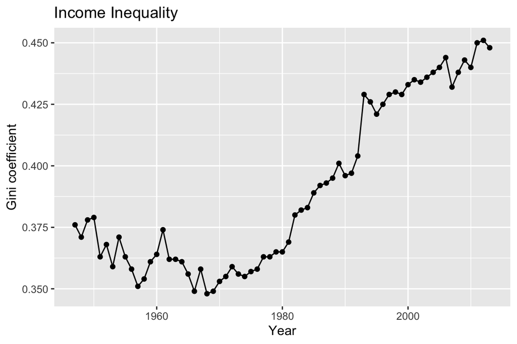

## Exercício:

Como uma legislatura dura 2 anos no caso americano, vamos usar o índice de Gini do último ano de cada legislatura. Por isso, desenvolva código que realize essa tarefa e aloque o resultado num vetor chamado `gini_congress`.

**Dica**: perceba que a base de dados está ou pode ser ordenada por ano. No pacote `tidyverse` a função `slice` pode ajudar nessa tarefa. Para mais delalhes sobre a função, veja: [slice](https://dplyr.tidyverse.org/reference/slice.html).

## Correlação

A correlação entre $x$ e $y$ representa como, em média, duas variáveis se movem juntas em relação às suas respectivas médias.

$$\begin{equation*}
r_{xy}={\frac {1}{n-1}}\sum _{i=1}^{n}\left({\frac {x_{i}-{\bar {x}}}{s_{x}}}\right)\left({\frac {y_{i}-{\bar {y}}}{s_{y}}}\right)
\end{equation*}$$

```r
# correlação
cor(gini_congress$gini, party_polarization$polarization)
```

```
## [1] 0.9418128
```

## Correlação: matriz

```r
mtcars %>% select(1:7)
```

## Correlação: matriz

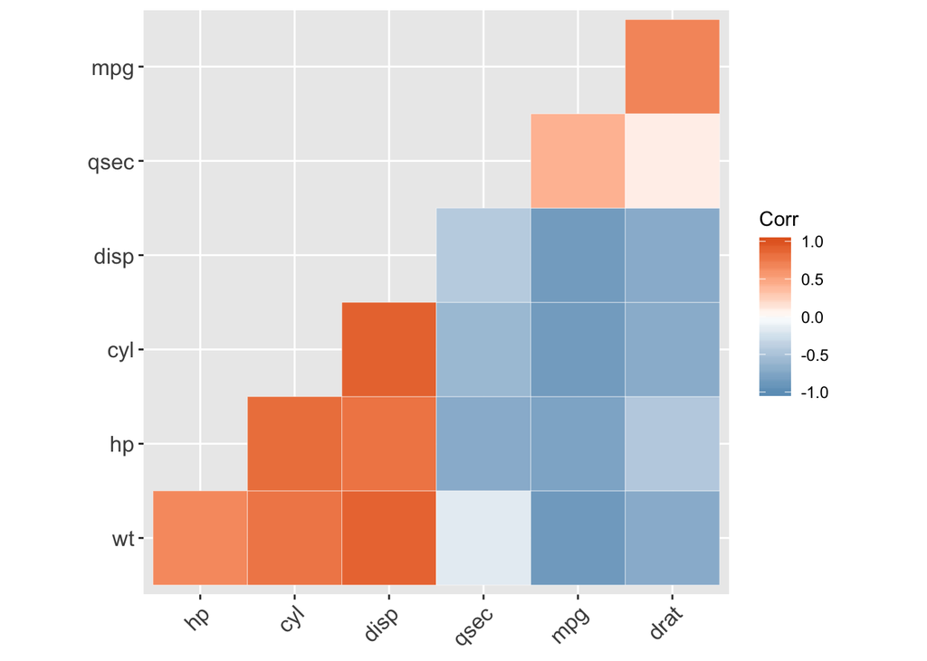

Para mais detalhes sobre o uso do pacote e da função, não deixe de ver esse tutorial: [Visualization of a correlation matrix using ggplot2](http://www.sthda.com/english/wiki/ggcorrplot-visualization-of-a-correlation-matrix-using-ggplot2)

## Material adicional

Além do livro e artigos mencionados, recomendamos:

- [QSS Tidyverse Code](https://jrnold.github.io/qss-tidy/)
- [Mosaic Plot](https://rpubs.com/tskam/mosaic_plot)
- [Mosaic Plot e ggplot2](https://cran.r-project.org/web/packages/ggmosaic/vignettes/ggmosaic.html)

## Tarefa da aula

As instruções da tarefa estão no arquivo `NN-class-ds4ir-assignment.rmd` da pasta `assignment` que se encontra na raiz desse projeto.